# Специфика медицинских данных

Sergey

2024-11-13

# Специфика медицинских данных. Домашнее задание

## Загрузка датасета

```r
data <- read_excel("data/raw/trauma.xlsx")
```

## Изучение структуры датасета

```r
str(data)
```

```
## tibble [1,024 × 12] (S3: tbl_df/tbl/data.frame)
##  $ id    : num [1:1024] 1 2 3 4 5 6 7 8 9 10 ...
##  $ Name  : chr [1:1024] "Jecelle Oberly" "Halie Mccone" "Kole Cook" "Patricia Davis" ...
##  $ Sex   : chr [1:1024] "Female" "Female" "Male" "Female" ...
##  $ Age   : num [1:1024] 24 35 39 20 63 60 63 26 20 25 ...
##  $ Height: chr [1:1024] "68\"" "69.8\"" "72.8\"" "70.5\"" ...
##  $ Weight: num [1:1024] 176 184 210 195 169 ...
##  $ SBP   : num [1:1024] 102 116 122 120 112 118 122 114 104 106 ...
##  $ DBP   : num [1:1024] 78 86 102 100 84 88 100 94 84 78 ...
##  $ FOUR  : num [1:1024] 10 9 12 11 9 13 10 11 10 7 ...
##  $ GSC   : num [1:1024] 8 7 12 9 7 11 9 10 9 5 ...
##  $ Hb    : num [1:1024] 11.4 12.2 15 12.2 12.4 15 11.8 14.4 11.4 12.2 ...
##  $ Death : num [1:1024] 1 0 0 0 1 0 0 0 0 1 ...
```

```r
#View(data)
summary(data)
```

```
##        id             Name               Sex                 Age
##  Min.   :   1.0   Length:1024        Length:1024        Min.   :18.00
##  1st Qu.: 256.8   Class :character   Class :character   1st Qu.:29.00
##  Median : 512.5   Mode  :character   Mode  :character   Median :41.00
##  Mean   : 512.5                                         Mean   :40.94
##  3rd Qu.: 768.2                                         3rd Qu.:53.00
##  Max.   :1024.0                                         Max.   :64.00
##     Height              Weight           SBP             DBP
##  Length:1024        Min.   :133.3   Min.   : 90.0   Min.   : 58.00
##  Class :character   1st Qu.:181.7   1st Qu.:106.0   1st Qu.: 78.00
##  Mode  :character   Median :193.9   Median :110.0   Median : 84.00
##                     Mean   :193.5   Mean   :110.8   Mean   : 84.78
##                     3rd Qu.:205.4   3rd Qu.:116.0   3rd Qu.: 90.00
##                     Max.   :253.1   Max.   :134.0   Max.   :110.00
##       FOUR             GSC               Hb           Death
##  Min.   : 0.000   Min.   : 3.000   Min.   : 0.0   Min.   :0.0000
##  1st Qu.: 7.000   1st Qu.: 6.000   1st Qu.:12.0   1st Qu.:0.0000
##  Median : 9.000   Median : 8.000   Median :13.1   Median :0.0000
##  Mean   : 8.853   Mean   : 7.785   Mean   :12.8   Mean   :0.3994
##  3rd Qu.:11.000   3rd Qu.:10.000   3rd Qu.:14.0   3rd Qu.:1.0000
##  Max.   :16.000   Max.   :14.000   Max.   :16.2   Max.   :1.0000
```

```r
data <- data %>%
  # Переведём некоторые величины в факторные
  mutate(across(c(Sex, FOUR, GSC), ~ as.factor(.x))) %>%
  # У летального исхода заменим 1 (наступил) на "Yes" и 0 (нет) на "No"  и переведём в фактор
  mutate(Death = factor(Death, labels = (c("No", "Yes")))) %>%
  # Выделим численную составляющую из роста и переведём в метры
  mutate(Height = round(0.01*2.54*as.numeric(sub('"', '', Height)), 3)) %>%
  # Переведём фунты в кг
  mutate(Weight = round(Weight/2.2, 1)) %>%
  # Рассчитаем индекс массы-тела
  mutate(BMI = (Weight / Height / Height) %>% round(1))

# Посчитаем количество пропущенных значений
sum(is.na(data))
```

```
## [1] 0
```

d – номер пациента в списке Name – имя фамилия пациента Sex – пол пациента Age – возраст пациента (лет) Height – рост пациента (дюймы1) Weight – масса тела пациента (фунты2) SBP – систолическое артериальное давление при поступлении (мм рт.ст.) DBP – диастолическое артериальное давление при поступлении (мм рт.ст.) FOUR – балл по шкале комы FOUR при поступлении GSC – балл по шкале комы Глазго при поступлении Hb – уровень гемоглобина при поступлении (г/дл) Death – летальный исход в течение 24 часов (1 – наступил, 0 – нет)

## Задание 1

Дайте описательную статистику для переменных, включённых в датасет. Дополнительно рассчитайте, у какого количества пациентов и в каком проценте случаев у пациентов был снижен уровень гемоглобина? Используйте следующие референтные значения (Мужчины: 13.5–16 г/дл, Женщины: 12–14 г/дл).

```r
# Описательная статистика
data %>%
  select(where(is.numeric) & !id) %>%
         summary()
```

```
##       Age            Height          Weight            SBP
##  Min.   :18.00   Min.   :1.621   Min.   : 60.60   Min.   : 90.0
##  1st Qu.:29.00   1st Qu.:1.770   1st Qu.: 82.58   1st Qu.:106.0
##  Median :41.00   Median :1.849   Median : 88.10   Median :110.0
##  Mean   :40.94   Mean   :1.840   Mean   : 87.97   Mean   :110.8
##  3rd Qu.:53.00   3rd Qu.:1.908   3rd Qu.: 93.40   3rd Qu.:116.0
##  Max.   :64.00   Max.   :2.029   Max.   :115.00   Max.   :134.0
##       DBP               Hb            BMI
##  Min.   : 58.00   Min.   : 0.0   Min.   :18.50
##  1st Qu.: 78.00   1st Qu.:12.0   1st Qu.:24.30
##  Median : 84.00   Median :13.1   Median :26.00
##  Mean   : 84.78   Mean   :12.8   Mean   :26.06
##  3rd Qu.: 90.00   3rd Qu.:14.0   3rd Qu.:27.80
##  Max.   :110.00   Max.   :16.2   Max.   :34.80
```

```r
len <- nrow(data)
summary_stats <- data %>%
  summarise(
    n = len %>% round(0),
    Mean_Age = mean(Age) %>% round(1),
    SD_Age = sd(Age) %>% round(1),
    Median_Age = median(Age)  %>% round(1),
    min_Age = min(Age),
    max_Age = max(Age),
    se_Age = (sd(Age) / sqrt(len)) %>% round(1),
    lower_ci_Age = (Mean_Age - qt(0.975, len - 1) * se_Age)  %>% round(1),
    upper_ci_Age = (Mean_Age + qt(0.975, len - 1) * se_Age)  %>% round(1),

    Mean_Height = mean(Height)  %>% round(1),
    SD_Height = sd(Height)  %>% round(1),
    Median_Height = median(Height) %>% round(1),
    min_Height = min(Height) %>% round(1),
    max_Height = max(Height) %>% round(1),
    se_Height = (sd(Height) / sqrt(len)) %>% round(1),
    lower_ci_Height = (Mean_Height - qt(0.975, len - 1) * se_Height) %>% round(1),
    upper_ci_Height = (Mean_Height + qt(0.975, len - 1) * se_Height) %>% round(1),

    Mean_Weight = mean(Weight) %>% round(1),
    SD_Weight = sd(Weight) %>% round(1),
    Median_Weight = median(Weight) %>% round(1),
    min_Weight = min(Weight),
    max_Weight = max(Weight),
    se_Weight = (sd(Weight) / sqrt(len)) %>% round(1),
    lower_ci_Weight = (Mean_Weight - qt(0.975, len - 1) * se_Weight) %>% round(1),
    upper_ci_Weight = (Mean_Weight + qt(0.975, len - 1) * se_Weight) %>% round(1),

    Mean_SBP = mean(SBP) %>% round(1),
    SD_SBP = sd(SBP) %>% round(1),
    Median_SBP = median(SBP) %>% round(1),
    min_SBP = min(SBP),
    max_SBP = max(SBP),
    se_SBP = (sd(SBP) / sqrt(len)) %>% round(1),
    lower_ci_SBP = (Mean_SBP - qt(0.975, len - 1) * se_SBP) %>% round(1),
    upper_ci_SBP = (Mean_SBP + qt(0.975, len - 1) * se_SBP) %>% round(1),

    Mean_DBP = mean(DBP) %>% round(1),
    SD_DBP = sd(DBP) %>% round(1),
    Median_DBP = median(DBP) %>% round(1),
    min_DBP = min(DBP),
    max_DBP = max(DBP),
    se_DBP = (sd(DBP) / sqrt(len)) %>% round(1),
    lower_ci_DBP = (Mean_DBP - qt(0.975, len - 1) * se_DBP) %>% round(1),
    upper_ci_DBP = (Mean_DBP + qt(0.975, len - 1) * se_DBP) %>% round(1),

    Mean_Hb = mean(Hb) %>% round(1),
    SD_Hb = sd(Hb) %>% round(1),
    Median_Hb = median(Hb) %>% round(1),
    min_Hb = min(Hb),
    max_Hb = max(Hb),
    se_Hb = (sd(Hb) / sqrt(len)) %>% round(1),
    lower_ci_Hb = (Mean_Hb - qt(0.975, len - 1) * se_Hb) %>% round(1),
    upper_ci_Hb = (Mean_Hb + qt(0.975, len - 1) * se_Hb) %>% round(1),

    Mean_BMI = mean(BMI) %>% round(1),
    SD_BMI = sd(BMI) %>% round(1),
    Median_BMI = median(BMI) %>% round(1),
    min_BMI = min(BMI),
    max_BMI = max(BMI),
    se_BMI = (sd(BMI) / sqrt(len)) %>% round(1),
    lower_ci_BMI = (Mean_BMI - qt(0.975, len - 1) * se_BMI) %>% round(1),
    upper_ci_BMI = (Mean_BMI + qt(0.975, len - 1) * se_BMI) %>% round(1)
  ) %>%
  #mutate(Number_of_Women = (plyr::count(data$Sex)$freq[count(data$Sex)$x == "Female"]) %>% round(0),
  #       Number_of_Men = (plyr::count(data$Sex)$freq[count(data$Sex)$x == "Male"]) %>% round(0),
  #       Dead = (plyr::count(data$Death)$freq[count(data$Death)$x == "Yes"]) %>% round(0),
  #       Alive = (plyr::count(data$Death)$freq[count(data$Death)$x == "No"]) %>% round(0)) %>%
  pivot_longer(everything(), names_to = "Statistics", values_to = "Values") %>%
  flextable()

summary_stats
```

| Statistics | Values |
| --- | --- |
| n | 1,024.0 |
| Mean_Age | 40.9 |
| SD_Age | 13.7 |
| Median_Age | 41.0 |
| min_Age | 18.0 |
| max_Age | 64.0 |
| se_Age | 0.4 |
| lower_ci_Age | 40.1 |
| upper_ci_Age | 41.7 |
| Mean_Height | 1.8 |
| SD_Height | 0.1 |
| Median_Height | 1.8 |
| min_Height | 1.6 |
| max_Height | 2.0 |
| se_Height | 0.0 |
| lower_ci_Height | 1.8 |
| upper_ci_Height | 1.8 |
| Mean_Weight | 88.0 |
| SD_Weight | 8.3 |
| Median_Weight | 88.1 |
| min_Weight | 60.6 |
| max_Weight | 115.0 |
| se_Weight | 0.3 |
| lower_ci_Weight | 87.4 |
| upper_ci_Weight | 88.6 |
| Mean_SBP | 110.8 |
| SD_SBP | 7.5 |
| Median_SBP | 110.0 |
| min_SBP | 90.0 |
| max_SBP | 134.0 |
| se_SBP | 0.2 |
| lower_ci_SBP | 110.4 |
| upper_ci_SBP | 111.2 |
| Mean_DBP | 84.8 |
| SD_DBP | 8.4 |
| Median_DBP | 84.0 |
| min_DBP | 58.0 |
| max_DBP | 110.0 |
| se_DBP | 0.3 |
| lower_ci_DBP | 84.2 |
| upper_ci_DBP | 85.4 |
| Mean_Hb | 12.8 |
| SD_Hb | 2.1 |
| Median_Hb | 13.1 |
| min_Hb | 0.0 |
| max_Hb | 16.2 |
| se_Hb | 0.1 |
| lower_ci_Hb | 12.6 |
| upper_ci_Hb | 13.0 |
| Mean_BMI | 26.1 |
| SD_BMI | 2.6 |
| Median_BMI | 26.0 |
| min_BMI | 18.5 |
| max_BMI | 34.8 |
| se_BMI | 0.1 |
| lower_ci_BMI | 25.9 |
| upper_ci_BMI | 26.3 |

```r
summary_stats_pretty <- data %>%
  select(Age, Height, Weight, BMI, SBP, DBP, Hb) %>%
    tbl_summary()

summary_stats_pretty
```

| **Characteristic** | **N = 1,024**<sup>1</sup> |
| --- | --- |
| Age | 41 (29, 53) |
| Height | 1.85 (1.77, 1.91) |
| Weight | 88 (83, 93) |
| BMI | 26.00 (24.30, 27.80) |
| SBP | 110 (106, 116) |
| DBP | 84 (78, 90) |
| Hb | 13.10 (12.00, 14.00) |

<sup>1</sup> Median (Q1, Q3)

```r
# Рассмотрим ситуацию по группам с различным исходом (Death)
summary_stats_death <- data %>%
  select(Age, Height, Weight, BMI, SBP, DBP, Hb, Death) %>%
    tbl_summary(by = Death) %>%
  add_p()

summary_stats_death
```

| **Characteristic** | **No** N = 615<sup>1</sup> | **Yes** N = 409<sup>1</sup> | **p-value**<sup>2</sup> |
| --- | --- | --- | --- |
| Age | 40 (29, 52) | 43 (30, 53) | 0.14 |
| Height | 1.85 (1.78, 1.91) | 1.85 (1.76, 1.90) | 0.3 |
| Weight | 88 (83, 94) | 88 (82, 93) | 0.3 |
| BMI | 26.00 (24.30, 27.70) | 26.00 (24.30, 27.80) | >0.9 |
| SBP | 114 (108, 118) | 106 (102, 110) | <0.001 |
| DBP | 88 (82, 94) | 80 (76, 86) | <0.001 |
| Hb | 13.50 (12.40, 14.30) | 12.60 (11.40, 13.30) | <0.001 |

<sup>1</sup> Median (Q1, Q3)  
<sup>2</sup> Wilcoxon rank sum test

```r
# Подсчёт количества и доли пациентов с пониженным гемоглобином
Hb_below_average <- data %>%
  mutate(Low_Hb = case_when(
    Sex == "Male" & Hb < 13.5 ~ TRUE,
    Sex == "Female" & Hb < 12 ~ TRUE,
    TRUE ~ FALSE
  )) %>%
  summarise(
    Low_Hb_Count = sum(Low_Hb),
    Low_Hb_Percentage = (sum(Low_Hb)/nrow(data))*100
  )

Hb_below_average
```

```
## # A tibble: 1 × 2
##   Low_Hb_Count Low_Hb_Percentage
##          <int>             <dbl>
## 1          474              46.3
```

## Задание 2

Рассчитайте индекс массы тела у пациентов (кг / м2). Каков был средний (M (SD)) уровень ИМТ у пациентов, включённых в исследование? Какая доля пациентов имела ожирение (ИМТ > 30)?

```r
# Индекс массы тела был рассчитан в разделе "Изучение структуры датасета"
data %>%
  select(id, Name, BMI) %>%
  head()
```

```
## # A tibble: 6 × 3
##      id Name              BMI
##   <dbl> <chr>           <dbl>
## 1     1 Jecelle Oberly   26.8
## 2     2 Halie Mccone     26.6
## 3     3 Kole Cook        27.9
## 4     4 Patricia Davis   27.7
## 5     5 Grace Cress      26.7
## 6     6 Joseph Benbrook  27.1
```

```r
# Расчёт среднего и стандартного отклонения ИМТ у пациентов
mean(data$BMI)
```

```
## [1] 26.05723
```

```r
sd(data$BMI)
```

```
## [1] 2.571885
```

```r
# Расчёт доли пациентов с повышенным BMI
High_BMI <- data[data$BMI > 30,]
Hight_BMI_percenatage <- ((nrow(High_BMI)/nrow(data))*100) %>% round(1)
print(Hight_BMI_percenatage)
```

```
## [1] 6.8
```

## Задание 3

Как выглядит ROC-кривая для предсказания летального исхода в течение 24 часов по переменной, характеризующей уровень гемоглобина? Постройте график. Чем может быть обусловлена такая форма кривой?

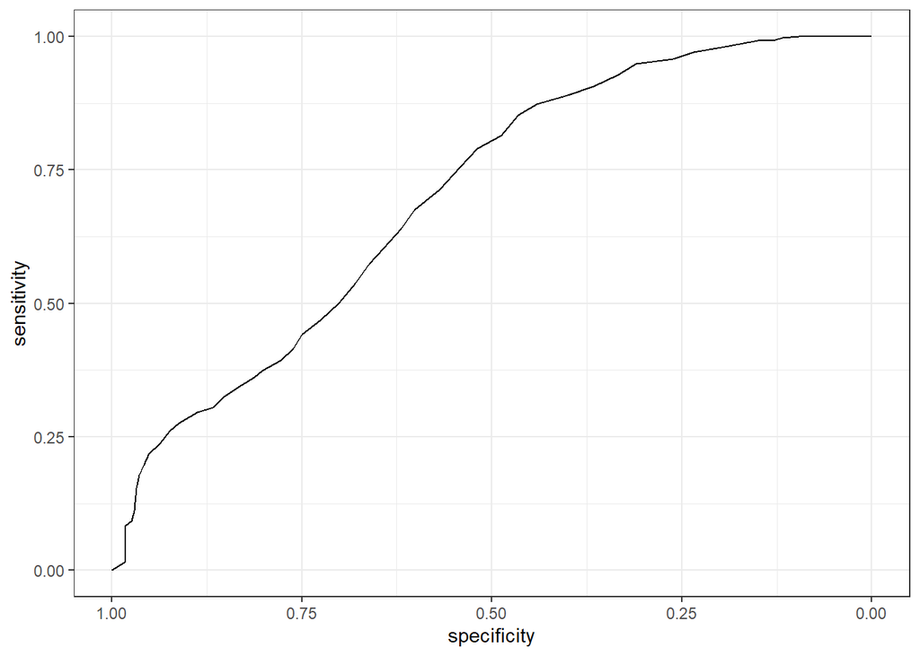

```r
roc_curve_Hb <- roc(Death ~ Hb,
                   data = data,
                   ci = T)
roc_curve_Hb %>%
    ggroc() +
    theme_bw()
```

```r
roc_curve_Hb
```

```
##
## Call:
## roc.formula(formula = Death ~ Hb, data = data, ci = T)
##
## Data: Hb in 615 controls (Death No) > 409 cases (Death Yes).
## Area under the curve: 0.7006
## 95% CI: 0.6691-0.7321 (DeLong)
```

В данном случае использовалась модель, в которой смерть через 24ч - зависимая переменная, а уровень гемоглобина - независимая (Death ~ Hb). Поскольку площадь под кривой примерно равна 0,7 и форма кривой значительно отличается от диагонали, следовательно модель Death ~ Hb обладает умеренной предсказательной способностью, т.е. при проверке крови пацинтов с черепно-мозговой травмой следует обращать внимание на пониженный гемоглобин и предпринимать действия, снижающие вероятнсоть наступления летального исхода.

## Задание 4

Чему равна площадь под ROC-кривой, которую вы построили в вопросе 3? Чему равен 95% двусторонний ДИ для площади под ROC-кривой, которую вы построили в вопросе 3?

```r
# Площадь под кривой
print(roc_curve_Hb$auc)
```

```
## Area under the curve: 0.7006
```

```r
# Доверительные интервалы
print(roc_curve_Hb$ci)
```

```
## 95% CI: 0.6691-0.7321 (DeLong)
```

Площадь - 0,7006, 95% ДИ - 0.6691-0.7321

## Задание 5

Проведите ROC-анализ и определите, какое пороговое значение является оптимальным для предсказания летального исхода в течение 24 часов по шкале комы Глазго. Какой чувствительностью и специфичностью обладает данный порог?

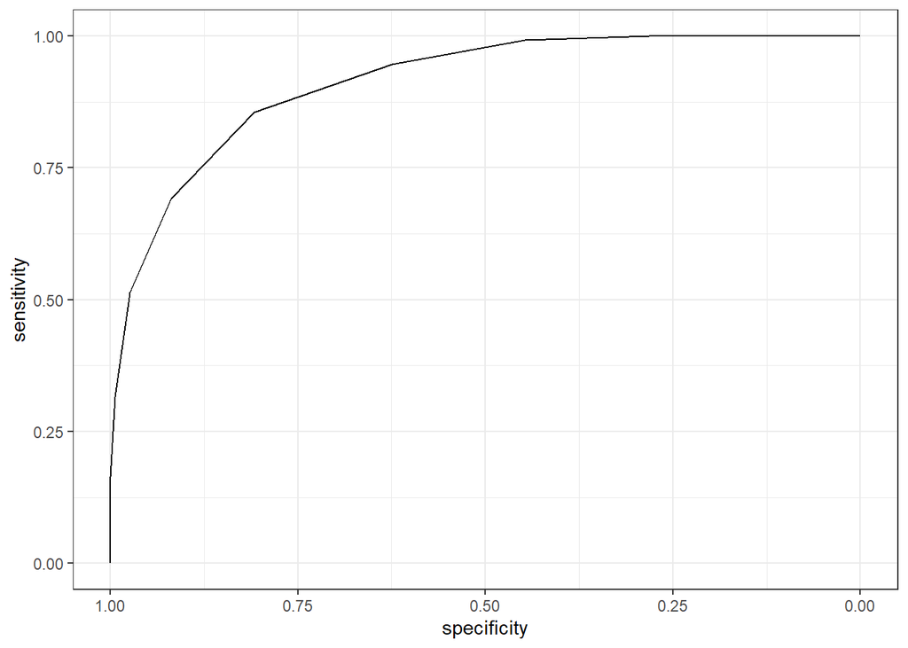

```r
roc_curve_GSC <- roc(Death ~ as.numeric(GSC),
                   data = data,
                   ci = T)
roc_curve_GSC %>%
    ggroc() +
    theme_bw()
```

```r
roc_curve_GSC
```

```
##
## Call:
## roc.formula(formula = Death ~ as.numeric(GSC), data = data, ci = T)
##
## Data: as.numeric(GSC) in 615 controls (Death No) > 409 cases (Death Yes).
## Area under the curve: 0.9124
## 95% CI: 0.8959-0.9289 (DeLong)
```

```r
# Выбираем наилучший порог
roc_curve_GSC %>% coords(x = "best", best.method = "closest.topleft")
```

```
##   threshold specificity sensitivity
## 1       5.5   0.8081301   0.8557457
```

```r
# Поскольку порог по шкале Глазго должен быть целочисленный, найдем значения чувствительности и специфичности у ближайших целочисленных баллов по шкале и сравним их значения с теми, что были вычислены в предыдущем шаге
roc_curve_GSC %>% coords(x = 5, input = "threshold", ret = c("specificity", "sensitivity"))
```

```
##   specificity sensitivity
## 1   0.8081301   0.8557457
```

```r
roc_curve_GSC %>% coords(x = 6, input = "threshold", ret = c("specificity", "sensitivity"))
```

```
##   specificity sensitivity
## 1   0.6243902   0.9462103
```

Поскольку балл по шкале Глазго целочисленный, то выбрать стоит порог в 5 балов по школе Глазго, тогда его значения чувствительности и специфичнсоти будут близки к найденному с помощью coords(x=“best”): Чувствительность - 0.8557457, специфичность - 0.8081301.

## Задание 5

Какая из количественных переменных в датасете (включая рассчитанный вами ранее ИМТ) обладает наибольшей площадью под ROC-кривой? Как вы можете интерпретировать это знание? Какая количественная переменная имеет наименьшую площадь?

```r
#Временно переведём FOUR и GSC в численные переменные иначе is.numeric их не найдёт
numeric_data <- data %>%
  select(where(is.numeric) & !id, FOUR, GSC) %>%
  mutate(FOUR = as.numeric(FOUR),
         GSC = as.numeric(GSC))

roc_curves <- NULL
# Расчет ROC-кривых для каждой количественной переменной
for (var in names(numeric_data)) {
  if (is.numeric(numeric_data[[var]])) {
    roc_curves[[var]] <- tryCatch({
      roc(data$Death ~ numeric_data[[var]], ci = TRUE)
    }, error = function(e) {
      message(paste("Error in calculating ROC for variable", var, ":", e$message))
      return(NULL)
    })
  }
}
roc_curves
```

```
## $Age
##
## Call:
## roc.formula(formula = data$Death ~ numeric_data[[var]], ci = TRUE)
##
## Data: numeric_data[[var]] in 615 controls (data$Death No) < 409 cases (data$Death Yes).
## Area under the curve: 0.5272
## 95% CI: 0.4911-0.5633 (DeLong)
##
## $Height
##
## Call:
## roc.formula(formula = data$Death ~ numeric_data[[var]], ci = TRUE)
##
## Data: numeric_data[[var]] in 615 controls (data$Death No) < 409 cases (data$Death Yes).
## Area under the curve: 0.4816
## 95% CI: 0.4455-0.5177 (DeLong)
##
## $Weight
##
## Call:
## roc.formula(formula = data$Death ~ numeric_data[[var]], ci = TRUE)
##
## Data: numeric_data[[var]] in 615 controls (data$Death No) > 409 cases (data$Death Yes).
## Area under the curve: 0.5178
## 95% CI: 0.4817-0.5539 (DeLong)
##
## $SBP
##
## Call:
## roc.formula(formula = data$Death ~ numeric_data[[var]], ci = TRUE)
##
## Data: numeric_data[[var]] in 615 controls (data$Death No) > 409 cases (data$Death Yes).
## Area under the curve: 0.7864
## 95% CI: 0.7589-0.814 (DeLong)
##
## $DBP
##
## Call:
## roc.formula(formula = data$Death ~ numeric_data[[var]], ci = TRUE)
```

[output cut: 25 more lines]

```
## Call:
## roc.formula(formula = data$Death ~ numeric_data[[var]], ci = TRUE)
##
## Data: numeric_data[[var]] in 615 controls (data$Death No) > 409 cases (data$Death Yes).
## Area under the curve: 0.9337
## 95% CI: 0.9196-0.9477 (DeLong)
##
## $GSC
##
## Call:
## roc.formula(formula = data$Death ~ numeric_data[[var]], ci = TRUE)
##
## Data: numeric_data[[var]] in 615 controls (data$Death No) > 409 cases (data$Death Yes).
## Area under the curve: 0.9124
## 95% CI: 0.8959-0.9289 (DeLong)
```

```r
s <- -Inf
s1 <- Inf
k <- NULL
k1 <- NULL
best_var <- NULL
worst_var <- NULL

for (var in names(numeric_data)) {
  if (var %in% names(roc_curves)) {
    if (roc_curves[[var]]$auc > s) {
      s <- roc_curves[[var]]$auc
      k <- roc_curves[[var]]
      best_var <- var
    }
    if (roc_curves[[var]]$auc < s1) {
      s1 <- roc_curves[[var]]$auc
      k1 <- roc_curves[[var]]
      worst_var <- var
    }
  }
}

# Наибольшая площадь
print("Наибольшая площадь")
```

```
## [1] "Наибольшая площадь"
```

```r
print(s)
```

```
## Area under the curve: 0.9337
```

```r
# Переменная с наибольшей площадью
print(best_var)
```

```
## [1] "FOUR"
```

```r
# ROC кривая для переменной с наибольшей площадью
k
```

```
##
## Call:
## roc.formula(formula = data$Death ~ numeric_data[[var]], ci = TRUE)
##
## Data: numeric_data[[var]] in 615 controls (data$Death No) > 409 cases (data$Death Yes).
## Area under the curve: 0.9337
## 95% CI: 0.9196-0.9477 (DeLong)
```

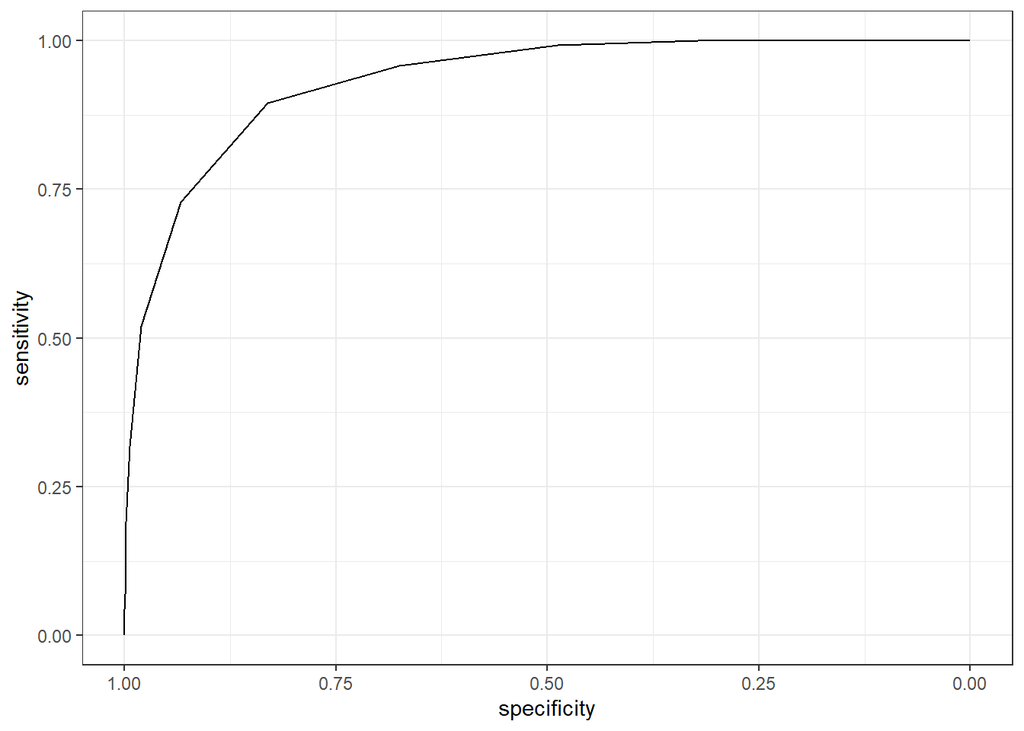

```r
k %>%
    ggroc() +
    theme_bw()
```

```r
# Наименьшая площадь
print("Наименьшая площадь")
```

```
## [1] "Наименьшая площадь"
```

```r
print(s1)
```

```
## Area under the curve: 0.4816
```

```r
# Переменная с наименьшей площадью
print(worst_var)
```

```
## [1] "Height"
```

```r
# ROC кривая для переменной с наименьшей площадью
k1
```

```
##
## Call:
## roc.formula(formula = data$Death ~ numeric_data[[var]], ci = TRUE)
##
## Data: numeric_data[[var]] in 615 controls (data$Death No) < 409 cases (data$Death Yes).
## Area under the curve: 0.4816
## 95% CI: 0.4455-0.5177 (DeLong)
```

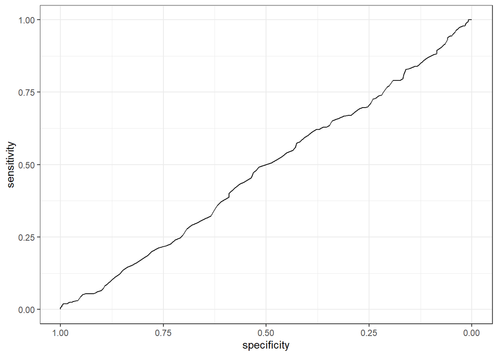

```r
k1 %>%
    ggroc() +
    theme_bw()
```

Таким образом, наибольшей площадью под ROC кривой будет обладать переменная FOUR - балл по шкале комы FOUR при поступлении. Наименьшей предсказательной способностью обладает переменная Height - рост. Таким образом, балл по шкале комы обладает наилучшей (отличной) предсказательной способностью летального исхода в течение 24 часов, а рост пациента, как и следовало ожидать, наименее информативен при предсказании летального исхода. Стоит отметить, что при определении балла по данной шкале учитываются глазные реакции, двигательные реакции, стволовые рефлексы, дыхательный паттерн, а также она точнее детализирует неврологический статус. Следовало ожидать, что данная шкала важна при учете состояния пациента, доставленного в реанимацию с черепно-мозговой травмой.